# Penguins

Castro, A.

2023-10-13

# Inicio

Píldoras_R. Material de formación

En esta práctica analizamos el dataset de PalmerPenguins

[mi_blog] https://agustincastro.es

Cargamos la librería de **palmerpenguins** y vemos que contiene un dataset que se llama **penguins**. Este es el que vamos a utilizar en esta práctica.

```r
# usar para ver los datasets que contiene la librería
data(package = "palmerpenguins")
```

```r
library(tidyverse) # librería para manipulación de datos
library(DT) # tablas paginadas
library(palmerpenguins)
library(ggplot2)
library(hrbrthemes)

data("penguins")
```

# Exploración general del dataset

Este es el dataset de **penguins**. Aquí puedes ver qué información contiene. He utilizado la librería **DT** y la función **datatable** para que la tabla sea paginada. Esto quiere decir que si hay muchas observaciones, no se mostrarán todas a la vez, sino que se mostrarán por páginas. En este caso, se muestran 10 observaciones por página.

```r
datatable(penguins, options = list(pageLength = 10))
```

|  | species | island | bill_length_mm | bill_depth_mm | flipper_length_mm | body_mass_g | sex | year |
| --- | --- | --- | --- | --- | --- | --- | --- | --- |
| 1 | Adelie | Torgersen | 39.1 | 18.7 | 181 | 3750 | male | 2007 |
| 2 | Adelie | Torgersen | 39.5 | 17.4 | 186 | 3800 | female | 2007 |
| 3 | Adelie | Torgersen | 40.3 | 18 | 195 | 3250 | female | 2007 |
| 4 | Adelie | Torgersen |  |  |  |  |  | 2007 |
| 5 | Adelie | Torgersen | 36.7 | 19.3 | 193 | 3450 | female | 2007 |
| 6 | Adelie | Torgersen | 39.3 | 20.6 | 190 | 3650 | male | 2007 |
| 7 | Adelie | Torgersen | 38.9 | 17.8 | 181 | 3625 | female | 2007 |
| 8 | Adelie | Torgersen | 39.2 | 19.6 | 195 | 4675 | male | 2007 |
| 9 | Adelie | Torgersen | 34.1 | 18.1 | 193 | 3475 |  | 2007 |
| 10 | Adelie | Torgersen | 42 | 20.2 | 190 | 4250 |  | 2007 |

[output cut: 334 more lines]

Para empezar nos puede interesar saber qué variables contiene el dataset. Con **colnames** podemos ver el nombre de estas. Con **length** podemos contar cuántas son.

```r
length(colnames(penguins))
```

```
## [1] 8
```

```r
colnames(penguins)
```

```
## [1] "species"           "island"            "bill_length_mm"
## [4] "bill_depth_mm"     "flipper_length_mm" "body_mass_g"
## [7] "sex"               "year"
```

Si queremos información sobre las variables y las observaciones podemos utilizar **str**. Interpretamos en resultado. Como vemos, hay 344 observaciones y los datos están en formato de “tibble”. Hay tres variables cualitativas: La variable **[species]** es un factor que cuenta con 3 niveles (hay datos para tres especies de pinguinos). Exactamente ocurre lo mismo para **[island]** (hay tres islas). Por último está **[sex]**, que indica el sexo de los pinguinos y es un factor con dos niveles (hembra o macho). El resto de variables son cuantitativas, siendo enteras (sin decimales = int) **[flipper_length_mm]**, **[body_mass_g]** y **[year]** y, numéricas con decimales **[bill_length_mm]** y **[bill_depth_mm]**.

```r
str(penguins)
```

```
## tibble [344 × 8] (S3: tbl_df/tbl/data.frame)
##  $ species          : Factor w/ 3 levels "Adelie","Chinstrap",..: 1 1 1 1 1 1 1 1 1 1 ...
##  $ island           : Factor w/ 3 levels "Biscoe","Dream",..: 3 3 3 3 3 3 3 3 3 3 ...
##  $ bill_length_mm   : num [1:344] 39.1 39.5 40.3 NA 36.7 39.3 38.9 39.2 34.1 42 ...
##  $ bill_depth_mm    : num [1:344] 18.7 17.4 18 NA 19.3 20.6 17.8 19.6 18.1 20.2 ...
##  $ flipper_length_mm: int [1:344] 181 186 195 NA 193 190 181 195 193 190 ...
##  $ body_mass_g      : int [1:344] 3750 3800 3250 NA 3450 3650 3625 4675 3475 4250 ...
##  $ sex              : Factor w/ 2 levels "female","male": 2 1 1 NA 1 2 1 2 NA NA ...
##  $ year             : int [1:344] 2007 2007 2007 2007 2007 2007 2007 2007 2007 2007 ...
```

Como muchas funciones trabajan sobre data frames, creamos uno **df**.

```r
df <- data.frame(penguins)
```

Podemos acceder rápidamente a un resumen de estadísticos descriptivos utilizando **sumary**.

```r
summary(df)
```

```
##       species          island    bill_length_mm  bill_depth_mm
##  Adelie   :152   Biscoe   :168   Min.   :32.10   Min.   :13.10
##  Chinstrap: 68   Dream    :124   1st Qu.:39.23   1st Qu.:15.60
##  Gentoo   :124   Torgersen: 52   Median :44.45   Median :17.30
##                                  Mean   :43.92   Mean   :17.15
##                                  3rd Qu.:48.50   3rd Qu.:18.70
##                                  Max.   :59.60   Max.   :21.50
##                                  NA's   :2       NA's   :2
##  flipper_length_mm  body_mass_g       sex           year
##  Min.   :172.0     Min.   :2700   female:165   Min.   :2007
##  1st Qu.:190.0     1st Qu.:3550   male  :168   1st Qu.:2007
##  Median :197.0     Median :4050   NA's  : 11   Median :2008
##  Mean   :200.9     Mean   :4202                Mean   :2008
##  3rd Qu.:213.0     3rd Qu.:4750                3rd Qu.:2009
##  Max.   :231.0     Max.   :6300                Max.   :2009
##  NA's   :2         NA's   :2
```

# Hacemos algunos cambios

Vamos a realizar una traducción y cambios en los nombres de las variables del dataset utilizando la función **rename**. Además, creamos una nueva variable **ratio** con la función **mutate**, que va a ser la relación entre la masa corporal y la longitud de la aleta. Con **head(penguins, 5)** podemos ver las 5 primeras observaciones del nuevo dataset, ahora llamado **df_col_rename**.

```r
df_col_rename <- df %>%
  rename(especies = species,
         isla = island,
         pico_longitud_mm = bill_length_mm,
         pico_grosor_mm = bill_depth_mm,
         aleta_longitud_mm = flipper_length_mm,
         masa_g = body_mass_g,
         sexo = sex,
         año = year) %>%
  mutate(ratio = masa_g / aleta_longitud_mm)
penguins <- df_col_rename
head(penguins, 5)
```

|  | especies | isla | pico_longitud_mm | pico_grosor_mm | aleta_longitud_mm | masa_g | sexo | año | ratio |
| --- | --- | --- | --- | --- | --- | --- | --- | --- | --- |
| 1 | Adelie | Torgersen | 39.1 | 18.7 | 181 | 3750 | male | 2007 | 20.71823 |
| 2 | Adelie | Torgersen | 39.5 | 17.4 | 186 | 3800 | female | 2007 | 20.43011 |
| 3 | Adelie | Torgersen | 40.3 | 18.0 | 195 | 3250 | female | 2007 | 16.66667 |
| 4 | Adelie | Torgersen | NA | NA | NA | NA | NA | 2007 | NA |
| 5 | Adelie | Torgersen | 36.7 | 19.3 | 193 | 3450 | female | 2007 | 17.87565 |

# Preguntas sobre los pinguinos

### Tamaño

¿Qué especie de pinguino tiene un mayor tamaño?

```r
penguins_means <- penguins %>%
  group_by(especies) %>%
  drop_na() %>%
  summarise(media_masa_g = mean(masa_g),
            media_aleta_longitud_mm = mean(aleta_longitud_mm),
            media_ratio = mean(ratio)) %>%
  arrange(desc(media_masa_g))
penguins_means
```

| especies | media_masa_g | media_aleta_longitud_mm | media_ratio |
| --- | --- | --- | --- |
| Gentoo | 5092.437 | 217.2353 | 23.41415 |
| Chinstrap | 3733.088 | 195.8235 | 19.04376 |
| Adelie | 3706.164 | 190.1027 | 19.48037 |

### ¿Dónde viven los más grandes?

Sabemos que hay datos biométricos para tres islas en el dataset. Nos preguntamos ¿Qué isla tiene los pinguinos más grandes? Para responder a esto, agrupamos por isla y calculamos ahora la media de **masa_g**. El resultado lo ordenamos de manera descendiente con **arrange**. Como vemos, la isla que tiene los pinguinos más grandes es **Biscoe**.

```r
penguins_island <- penguins %>%
  group_by(isla) %>%
  drop_na() %>%
  summarise(media_masa_g = mean(masa_g)) %>%
  arrange(desc(media_masa_g))
penguins_island
```

| isla | media_masa_g |
| --- | --- |
| Biscoe | 4719.172 |
| Dream | 3718.902 |
| Torgersen | 3708.511 |

### Especies en Biscoe

```r
# data frame con los pinguinos de la isla Biscoe
penguins_biscoe <- penguins %>%
  filter(isla == "Biscoe") %>%
  drop_na() %>%
  select(especies, isla, pico_longitud_mm, pico_grosor_mm, aleta_longitud_mm, masa_g, sexo, año, ratio) %>%
  arrange(desc(especies))

# especies que hay en la isla Biscoe
unique(penguins_biscoe$especies)
```

```
## [1] Gentoo Adelie
## Levels: Adelie Chinstrap Gentoo
```

```r
# número de observaciones de cada especie
sum(penguins_biscoe$especies == "Adelie")
```

```
## [1] 44
```

```r
sum(penguins_biscoe$especies == "Gentoo")
```

```
## [1] 119
```

```r
sum(penguins_biscoe$especies == "Chinstrap")
```

```
## [1] 0
```

### Observaciones de sp en cada isla

Vamos a representar el número de observaciones de cada especie, en cada una de las islas.

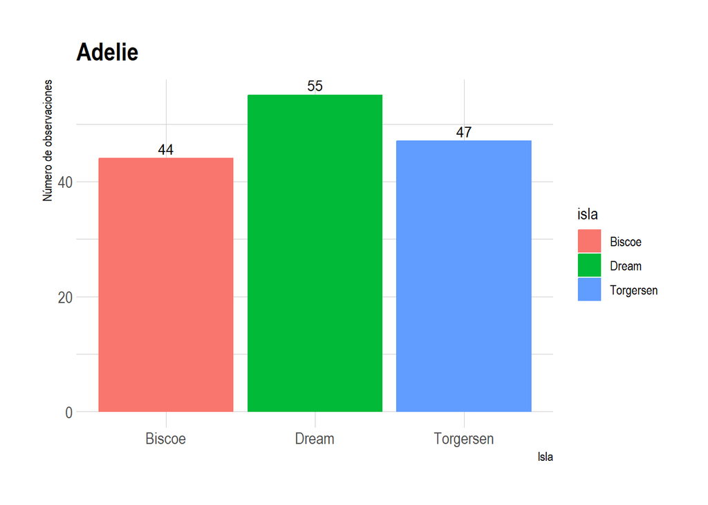

```r
penguins_island_especies <- penguins %>%
  group_by(isla) %>%
  drop_na() %>%
  summarise(Adelie = sum(especies == "Adelie"),
            Chinstrap = sum(especies == "Chinstrap"),
            Gentoo = sum(especies == "Gentoo"))

penguins_island_especies %>%
  ggplot(aes(x = isla, y = Adelie, color = isla)) +
  geom_col(aes(fill = isla), position = "dodge") +
  labs(title = "Adelie",
       x = "Isla",
       y = "Número de observaciones") +
  geom_text(aes(label = Adelie), position = position_dodge(width = 0.9),
            color = "black", size = 3.5, vjust = -0.4) +
  theme_ipsum()
```

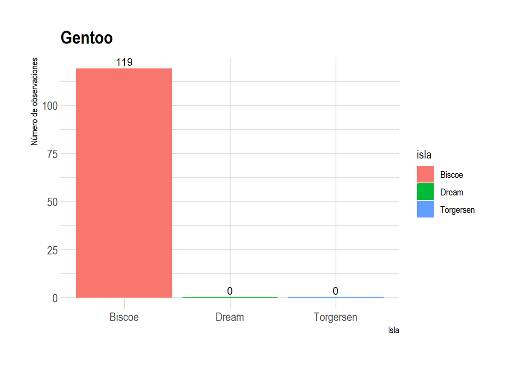

```r
penguins_island_especies %>%
  ggplot(aes(x = isla, y = Gentoo, color = isla)) +
  geom_col(aes(fill = isla), position = "dodge") +
  labs(title = "Gentoo",
       x = "Isla",
       y = "Número de observaciones") +
  geom_text(aes(label = Gentoo), position = position_dodge(width = 0.9),
            color = "black", size = 3.5, vjust = -0.4) +
  theme_ipsum()
```

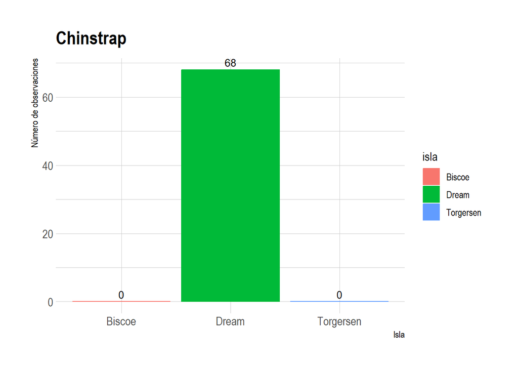

```r
penguins_island_especies %>%
  ggplot(aes(x = isla, y = Chinstrap, color = isla)) +
  geom_col(aes(fill = isla), position = "dodge") +
  labs(title = "Chinstrap",
       x = "Isla",
       y = "Número de observaciones") +
  geom_text(aes(label = Chinstrap), position = position_dodge(width = 0.9),
            color = "black", size = 3.5, vjust = -0.4) +
  theme_ipsum()
```

### Dimofismo sexual

**¿Hay dimorfismo sexual en relación al tamaño de machos y hembras en las especies estudiadas (masa corporal y longitud de las aletas)?** Para contestar a esta pregunta necesitamos crear un nuevo dataframe con los valores medios de las variables para cada una de las especies. Para ello, agrupamos por especie y sexo y calculamos la media de las variables. El resultado lo ordenamos de manera descendiente con **arrange**. Como vemos, **en las tres especies los machos son más grandes que las hembras, en ambas variables**.

```r
penguins_dimorfismo_sexual_masa <- penguins %>%
  group_by(especies, sexo) %>%
  drop_na() %>%
  summarise(media_masa_g = mean(masa_g)) %>%
  arrange(especies, desc(sexo))
penguins_dimorfismo_sexual_masa
```

| especies | sexo | media_masa_g |
| --- | --- | --- |
| Adelie | male | 4043.493 |
| Adelie | female | 3368.836 |
| Chinstrap | male | 3938.971 |
| Chinstrap | female | 3527.206 |
| Gentoo | male | 5484.836 |
| Gentoo | female | 4679.741 |

```r
penguins_dimorfismo_sexual_aleta <- penguins %>%
  group_by(especies, sexo) %>%
  drop_na() %>%
  summarise(media_aleta_longitud_mm = mean(aleta_longitud_mm)) %>%
  arrange(especies, desc(sexo))
  penguins_dimorfismo_sexual_aleta
```

| especies | sexo | media_aleta_longitud_mm |
| --- | --- | --- |
| Adelie | male | 192.4110 |
| Adelie | female | 187.7945 |
| Chinstrap | male | 199.9118 |
| Chinstrap | female | 191.7353 |
| Gentoo | male | 221.5410 |
| Gentoo | female | 212.7069 |

Utilizando el data frame de penguins_dimorfismo_sexual_masa, vamos a representar gráficamente la masa de machos y hembras en las tres especies de pinguinos. Para ello, utilizamos la función **ggplot**. Con **aes** indicamos que en el eje x queremos la especie y en el eje y la masa corporal. Con **geom_col** indicamos que queremos representar los datos en forma de columnas. Con **fill** indicamos que queremos que las columnas se rellenen con el color de la variable sexo. Con **labs** añadimos el título y las etiquetas de los ejes. Con **theme** cambiamos el color de fondo del gráfico.

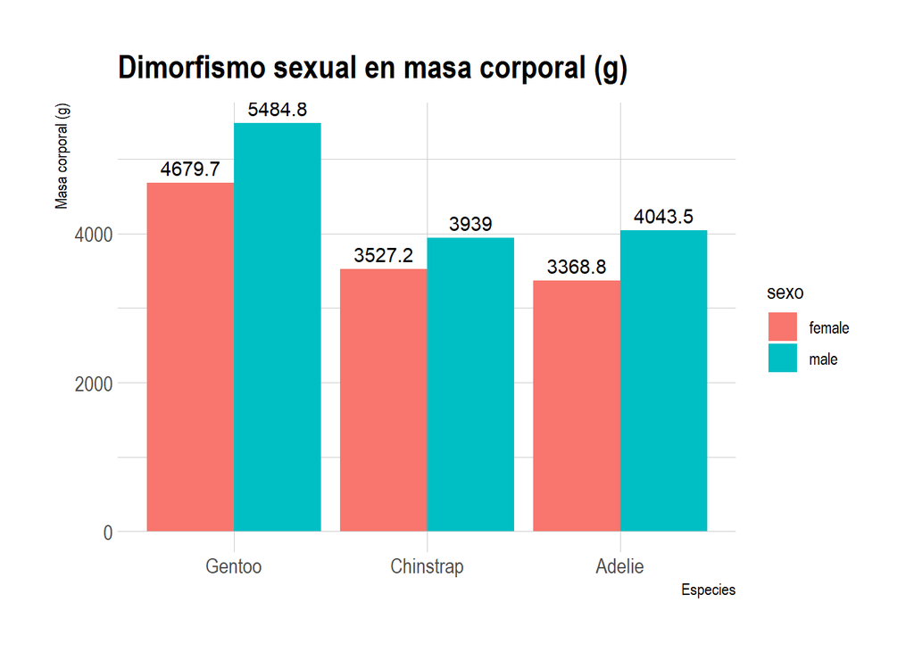

```r
ggplot(penguins_dimorfismo_sexual_masa, aes(x = reorder(especies, -media_masa_g),
                                            y = media_masa_g)) +
  geom_col(aes(fill = sexo), position = "dodge") +
  labs(title = "Dimorfismo sexual en masa corporal (g)",
       x = "Especies",
       y = "Masa corporal (g)") +
  geom_text(aes(label = round(media_masa_g, 1), group = sexo),
            position = position_dodge(width = 0.9), vjust = -0.5) +
  theme_ipsum()
```

De la misma forma podemos hacerlo para la longitud de las aletas.

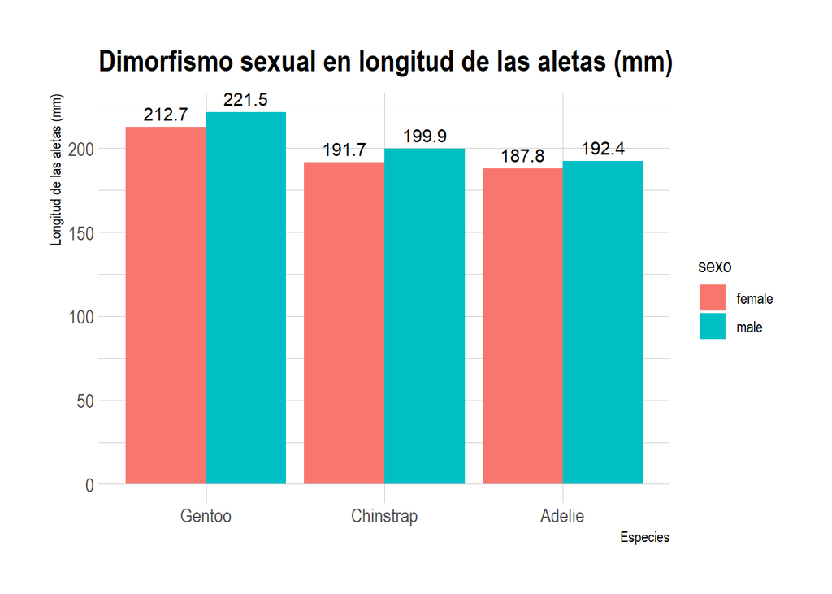

```r
ggplot(penguins_dimorfismo_sexual_aleta, aes(x = reorder(especies,
                                                         -media_aleta_longitud_mm),
                                             y = media_aleta_longitud_mm)) +
  geom_col(aes(fill = sexo), position = "dodge") +
  labs(title = "Dimorfismo sexual en longitud de las aletas (mm)",
       x = "Especies",
       y = "Longitud de las aletas (mm)") +
  geom_text(aes(label = round(media_aleta_longitud_mm, 1), group = sexo),
            position = position_dodge(width = 0.9), vjust = -0.5) +
  theme_ipsum()
```